# The Social Conditioning of Fear

Authors

Alejandra Pedraza

W. Jamie Yang

Abstract

Fear at night has been perceived as a form of gender-based violence with sexual assault implications. However, this more insidious and everyday forms of harassment are frequently not captured by common survey instruments. In this study, we investigate the inequalities in terms of fear of walking alone at night among the US adult population and mapping out the patterns of disparities along the axes of race, gender, sexual orientation, citizenship status, and education. We use the 2022 data from the General Social Survey (GSS) and the data science tools from EDLD 651 class to delineate the data distribution and basic correlations between fear of walking alone at night and our other variables of interest. Our findings suggest that fear at night differs by race, gender, subjective health, and neighborhood diversity. Consistent with previous research, women were also more likely than men to report fear at night. Importantly, groups with multiply marginalized social identities are likely to report higher rates of fear at night.

# Introduction

Individuals’ report of fear have been shown to relate to a wide range of contextual factors, such as neighborhood composition and community crime rates (Hale 1996; Warr 1990), and individual sociodemographic characteristics, such as gender, sexual orientation, income, age, health condition, and immigration status (LaGrange and Ferraro 1989; Otis 2007; Madriz 2023). To be more specific, this body of scholarship has found spatial and neighborhood characteristics have a significant impact on individuals’ self-reported fear of crime, as those who live in areas with high levels of community disorder have reported more fear than those who do not live in such communities (Rountree and Land 1996). Also, due to the popularity density in urban areas, residents of these areas have reported higher levels of fear at night, potentially because of feelings of alienation and unfamiliarity among residents (Bennett and Flavin 1994).

Especially, the role of gender in fear of crime has been well documented in victimization research (Cops and Pleysier 2011; Snedker 2006; Schnitzer et al. 2010; Elizabeth A. Stanko 1993). Early scholarship emphasized that women tend to report more fear than men (Elizabeth Anne Stanko 1990), with some initial research investigating the seeming disjuncture between women’s fear and their actual experiences of victimization, as women were often found to report high levels of fear for crimes that they were at relatively little risk of experiencing (Hough, Mayhew, et al. 1983). Subsequent studies suggested that women’s fear should be understood in the context of the many potential threats that women confront, including their heightened risk of sexual assault (Elizabeth A. Stanko 1993). Therefore, fear at night is gradually perceived as a manifestation of gender-based violence with sexual assault implications, though acknowledging that sexual assault is merely one among many potential forms of crime. However, the more insidious and everyday forms of harassment are frequently not captured by common survey instruments—they regularly privilege the more obvious or extreme forms of victimization and fail to account for the routine forms of violence that women confront (Moran et al. 2003). We focus our attention on this less intrusive but omnipresent form of everyday violence and examine the unequal effects it has on different populations. We ask: what groups of people are more likely to have experienced fear of walking alone at night in their neighborhood?

Historically, despite all the aforementioned contexts and individual-level characteristics being identified as salient to individuals’ self-reported fear at night, they were usually studied in isolation. Notably, scholars have tended to focus either on individual-level characteristics, such as race and sexual orientation, or on physically defined contexts like schools and neighborhoods and social contexts like networks, families, with little consideration of the joint contributions of multiple contexts and multilevel effects simultaneously. To fill this gap in knowledge, we hypothesize that, similar to “the social determinants of health” (Krieger 2001), there exist the social determinants of fear—intersectional social positionalities impact the likelihood of individuals’ sense of threat from social surroundings, i.e., fear at night.

This is an exploratory project for a dissertation chapter idea that one of the co-authors wants to pursue. With descriptive statistics, we are interested in investigating the inequalities in terms of fear of walking alone at night among the US adult population and mapping out the patterns of disparities along the axes of race, gender, sexual orientation, citizenship status, and education. We use the 2022 data from the General Social Survey (GSS) and the data science tools from EDLD 651 class to delineate the data distribution and basic correlations between “fear of walking alone at night” and our other variables of interest.

# Methods

This study draws data from the General Social Survey (GSS). The GSS is a nationally representative interview-based survey that has collected longitudinal data since 1972. The GSS contains questions on demographics, behaviors, attitudes, civil liberties, crime and violence, intergroup tolerance, morality, national spending priorities, psychological well-being, social mobility, stress, and traumatic events. Our study is limited to data collected during the 2022 wave and we draw primarily on demographic and well-being variables.

Our dependent variable is coded as **fear** by the GSS. Respondents were asked, “*Is there any area right around here–that is, within a mile–where you would be afraid to walk alone at night?*” During the 2022 wave, there were 3,544 answers coded as follows: 878 = yes, 1440 = no, and 1226 = NA. Notably, the GSS codes missing values with multiple indicators–“.i: Inapplicable,” “.n: No answer,” “.d: Do not Know/Cannot Choose,” and “.s: Skipped on Web.” For the purposes of our preliminary study, we coded all missing data as NA. Furthermore, we applied fixed removal of NAs for our dependent variable and we ran mice imputations for all other variables to create a more robust dataset that is necessary for further modeling.

Our control and independent variables are representative of two different dimensions we sought to capture. The first dimension is individual-level or social identity characteristics:

- **born**: Were you born in this country?
- **age**: Respondent’s age in numeric values.
- **sexnow1**: Do you describe yourself as male, female, or transgender?
- **sexornt**: Which of the following best describes you? [1] “Gay, lesbian, or homosexual” [2] Bisexual [3] Heterosexual or straight [99] “Refused”
- **racerank1**: If you had to choose, which of these races do you identify most with?
- **hispanic**: Are you Spanish, Hispanic, or Latino/Latina? IF YES: Which group are you from?
- **degree**: Respondent’s (highest educational) degree.
- **uscitzn**: Are you a US citizen?
- **dwelown**: (Do you/Does your family) own your (home/apartment), pay rent, or what?

Informed by theory, race is an important co-variate for our models as racialization serves to structure the daily lives of individuals based on where they fall on the Black-white spectrum, their opportunities, and their sense of belonging (Bonilla-Silva 2022; Omi and Winant 2015). First, we sought to create a combined race variable from the variables **race** and **hispanic**. After looking at the data, we saw that **race** was coded as “Black, White, or Other.” This does not provide the control we need as it omits those in the “racial middle” that are more likely to identify with a panethnic label and reject the Black-white binary (Mora 2014; O’Brien 2008; Rodriguez 2000). Instead, we opted to use the **racerank1** variable, because participants were able to select from 16 different options: White, Black or African-American, Asian Indian, Chinese, Filipino, Japanese, Korean, Vietnamese, Other, Asian, Guamanian or Chamorro, Samoan, Other Pacific Islander, Some other race, and Hispanic. We factored and recoded these to White, Black, Hispanic, Asian, NHPI (Native Hawaiian or Pacific Islander), AIAN (American Indian, Alaska Native), and Other. We understand that these categories are problematic and contentious (Haney-López 2006; Dowling 2014), however they are the standard with quantitative data.

Similarly, gender was a contentious variable to account for. Although the GSS has several questions aimed at capturing respondent’s gender, we found them to be lacking in breadth. For example, the GSS codes **sex** within a Male/Female binary based solely on interviewer discretion. Ultimately, we opted to use **sexnow1** since it was the variable that most closely captured self-described gender. However, it remains problematic as respondents were only provided four choice: Male, Female, Transgender, and None of these. Out of 2306 cases, only 10 were coded as Transgender and 9 as None of these. Therefore, this is by no means a representative sample on gender minority population. The fact that the GSS data is primarily collected through in-person field interviews increases the possibility that minority-identifying individuals may not disclose their accurate identity information to avoid being associated with negative stereotypes.

Another important variable we sought to control for was citizenship status, since citizenship status and the associated stigma of illegality and threat of deportation have been found to increase fear in daily life (Golash-Boza 2015; Kline 2019). However, GSS data is not conducive to controlling for this variable due to the large number of NAs. Out of 2318 cases, 2164 were coded as NAs. In future work, we will pursue data options that allow the analysis ton include citizenship status.

The second dimension we sought to capture was community-level characteristics that would potentially affect one’s sense of safety. For this dimension, we drew on the following variables:

- **attend**: How often do you attend religious services?
- **raclive**: Are there any (“whites” for black respondents, “blacks” for non-black respondents) living in this neighborhood now?

These variables seek to account for respondent’s social embeddedness and networks of support. Specifically, **raclive** is an important variable to consider as it accounts for neighborhood composition, in the absence of a neighborhood dissimilarity index. While this variable only looks at Black-white racial composition, it provides a good benchmark to examine broader racial antagonisms. Research has documented the associated fears white experience when Blacks or people of other racial backgrounds move into their neighborhood (Lacayo 2017; Massey 2020).

The third dimension we considered were individual-level health-related and attitudinal variables. Good mental and physical health status is positively correlated with individuals’ evaluation of their life conditions and affects how likely individuals are to report positive emotions about their life (Dwyer-Lindgren et al. 2017). Additionally, social capital—-such as levels of interpersonal trust and norms of reciprocity and mutual aid–is believed to play an important role in explaining variations in health status across geographic localities (Kawachi 1999). Therefore, we included the following variables that capture respondents’ self-reported health status and assessment of interpersonal social climate:

- **happy**: Taken all together, how would you say things are these days–would you say that you are very happy, pretty happy, or not too happy?
- **health**: Would you say your own health, in general, is excellent, good, fair, or poor?
- **helpful**: Would you say that most of the time people try to be helpful, or that they are mostly just looking out for themselves?
- **fair**: Do you think most people would try to take advantage of you if they got a chance, or would they try to be fair?
- **trust**: Generally speaking, would you say that most people can be trusted or that you can’t be too careful in dealing with people?
- **partnrs5**: since February/March 2015, and including the past 12 months, how many sex partners have you had in that five year period?

## Data Script

**View Code**

```r
gss <- import(here("data", "GSS.xlsx")) %>%
  as_tibble() %>%
  clean_names()
```

**View Code**

```r
gss2022 <- gss %>%
  filter(year == "2022")
```

**View Code**

```r
data <- gss2022 %>%
    select(age, sex, sexnow1, sexornt, degree, attend, raclive, happy, health, helpful, fair, trust, fear, partnrs5, racerank1, uscitzn, dwelown)
```

**View Code**

```r
missing_vec <- c(".i:  Inapplicable", ".n:  No answer", ".d:  Do not Know/Cannot Choose", ".s:  Skipped on Web")

tidydata <- data %>%
  mutate(across(c(age, sex, sexnow1, sexornt, degree, attend, raclive, happy, health, helpful, fair, trust, fear, partnrs5, racerank1, uscitzn, dwelown),
                ~ifelse(. %in% missing_vec, NA_character_, .)))
```

**View Code**

```r
tidydata <- tidydata %>%
  filter(!is.na(fear)) %>%
  mutate(age = as.numeric(age)) %>%
  mutate(raclive = as.factor(raclive)) %>%
  mutate(sexnow1 = as.factor(sexnow1)) %>%
  mutate(fear = factor(case_when(fear == "NO" ~ "no",
                                 fear == "YES" ~ "yes"))) %>%
  mutate(racecombo =
           factor(case_when(racerank1 == "White" ~ "White",
                     racerank1 == "Black or African-American" ~ "Black",
                     racerank1 == "Hispanic" ~ "Hispanic",
                     racerank1 == "Asian Indian" | racerank1 ==  "Chinese" |
                       racerank1 ==  "Filipino" | racerank1 ==  "Japanese" |
                       racerank1 ==  "Korean" |  racerank1 ==  "Vietnamese" |
                       racerank1 ==  "Other Asian" ~ "Asian",
                     racerank1 == "American Indian or Alaska Native" ~ "AIAN",
                     racerank1 == "Guamanian or Chamorro" | racerank1 == "Samoan" |
                       racerank1 == "Other Pacific Islander" ~ "NHPI",
                      racerank1 == "Some other race" ~ "Other"))) %>%
  mutate(racecombo = fct_relevel(racecombo,
              "White",
              "Black",
              "Asian",
              "Hispanic",
              "AIAN",
              "NHPI",
              "Other")) %>%
  mutate(partnrs5 =
           factor(case_when(partnrs5 == "NO PARTNERS" ~ "0",
                            partnrs5 == "1 PARTNER" | partnrs5 == "2 PARTNERS" |
                              partnrs5 == "3 PARTNERS" |
                              partnrs5 == "4 PARTNERS" ~ "Less than 5",
                            partnrs5 == "5-10 PARTNERS" ~ "5-10",
                            partnrs5 == "11-20 PARTNERS" ~ "11-20",
                            partnrs5 == "21-100 PARTNERS" ~ "21-100",
                            partnrs5 == "MORE THAN 100 PARTNERS" ~ "100 or more",
                            .default = NA))) %>%
  mutate(partnrs5 = fct_relevel(partnrs5,
                                "0",
                                "Less than 5",
                                "5-10",
                                "11-20",
                                "21-100",
                                "100 or more")) %>%
  mutate(uscitzn =
           factor(case_when(uscitzn == "A u.s. citizen" | uscitzn == "A u.s. citizen born in puerto rico, the u.s. virgin islands, or the northern marianas islands (if volunteered)" |
                       uscitzn == "Born outside of the u.s. to parents who were u.s. citizens at that time (if volunteered)" ~ "Yes",
                     uscitzn == "Not a u.s. citizen" ~ "No",
                     .default = NA))) %>%
   mutate(dwelown =
           factor(case_when(dwelown == "Own or is buying" ~ "Owner",
                            dwelown == "Pays rent" ~ "Renter",
                            dwelown == "Other" ~ "Other"))) %>%
  mutate(degree = fct_relevel(degree,
                              "Less than high school",
                              "High school",
                              "Associate/junior college",
                              "Bachelor's",
                              "Graduate")) %>%
  mutate(attend = fct_relevel(attend,
                              "Never",
                              "Less than once a year",
                              "About once or twice a year",
                              "2-3 times a month",
                              "Nearly every week",
                              "Every week",
                              "Several times a week")) %>%
  mutate(happy = fct_relevel(happy,
                             "Not too happy",
                             "Pretty happy",
                             "Very happy",)) %>%
  mutate(health = fct_relevel(health,
                              "Poor",
                              "Fair",
                              "Good",
                              "Excellent")) %>%
  mutate(helpful = fct_relevel(helpful,
                               "Looking out for themselves",
                               "Try to be helpful",
                               "Depends")) %>%
  mutate(fair = fct_relevel(fair,
                            "Would take advantage of you",
                            "Would try to be fair",
                            "Depends")) %>%
  mutate(trust = fct_relevel(trust,
                             "Can't be too careful",
                             "Can trust",
                             "Depends"))
```

**View Code**

```r
gss_subset <- tidydata %>%
  select(age, sexnow1, racecombo, uscitzn, degree, attend, raclive, happy, health, partnrs5, fear)
```

**View Code**

```r
overall_fear <- gss_subset %>%
  mutate(fear = case_when(fear == "no" ~ "0",
                                 fear == "yes" ~ "1")) %>%
  select(fear)
mean_fear <- mean(as.numeric(overall_fear$fear, na.rm=TRUE))
```

**View Code**

```r
complete5 <- mice(gss_subset,
                 m = 5,
                 seed = 25)

summary(complete(complete5, 1))

temp5 <- complete(complete5, action = "long", include = TRUE)

tidydata_complete <- as.mids(temp5)

save(tidydata_complete, file = "data/tidydata_complete.RData")
```

# Results

In the absence of running models, in this section we will discuss descriptive statistics through a series of tables and plots. We seek to show how the experience of fear differed across different measures of individual-level and community-level characteristics. To begin with, across our sample of 2318 cases, mean fear was calculated at 0.3787748. One thing to note about the interpretation of this value is, because we operationalized the variable **fear** as a dichotomous variable with answers being “Yes = 1” and “No = 0”, this mean value approximates “the likelihood for an individual in our sample to report the experience of fear of walking alone at night in their neighborhood”.

First, we examined how fear is experienced across race and gender. As Table 1 shows, Transgender and Female respondents had higher mean fear rate than respondents who identified as Male. Particularly, respondents that were Transgender expressed greater fear, but this may be indicative of sample representation. For example, only one respondent identified as both Hispanic and Transgender, and since they responded affirmative to the question, this finding is heavily skewed. However, it’s important to note that Transgender individuals have been subject to more frequent and more severe forms of sexual violence and thus, experiencing more fear related to gender-based crime and engaging in more gendered tactics to protect themselves (Schilt and Westbrook 2009).

**View Code**

```r
gss_subset %>%
  filter(!is.na(racecombo)) %>%
  filter(racecombo != "Other") %>%
  filter(!is.na(sexnow1)) %>%
  filter(sexnow1 != "None of these") %>%
  pivot_longer(
    cols = fear,
    names_to = "fear",
    values_to = "answer") %>%
  select(racecombo, answer, sexnow1) %>%
  mutate(fear = as.numeric(case_when(answer == "no" ~ "0",
                                 answer == "yes" ~ "1"))) %>%
  select(racecombo, fear, sexnow1) %>%
  group_by(racecombo, sexnow1) %>%
  summarize(mean_fear = mean(fear)) %>%
  pivot_wider(
    names_from = sexnow1,
    values_from = mean_fear
  ) %>%
  kable(caption = "Social Fear by Race and Gender",
        col.names = c("Race", "Female", "Male", "Transgender"),
        digits = 3) %>%
  kableExtra::row_spec(0:6, background = "white")
```

Table 1: Mean fear by race and gender calculated from respondents affirmative answer to GSS question, Is there any area right around here–that is, within a mile–where you would be afraid to walk alone at night?

| Race | Female | Male | Transgender |
| --- | --- | --- | --- |
| White | 0.458 | 0.244 | 0.714 |
| Black | 0.491 | 0.324 | 0.500 |
| Asian | 0.614 | 0.318 | NA |
| Hispanic | 0.531 | 0.333 | 1.000 |
| AIAN | 0.609 | 0.278 | NA |
| NHPI | 1.000 | 0.000 | NA |

Figure 1 does a good job at plotting this relationship.

**View Code**

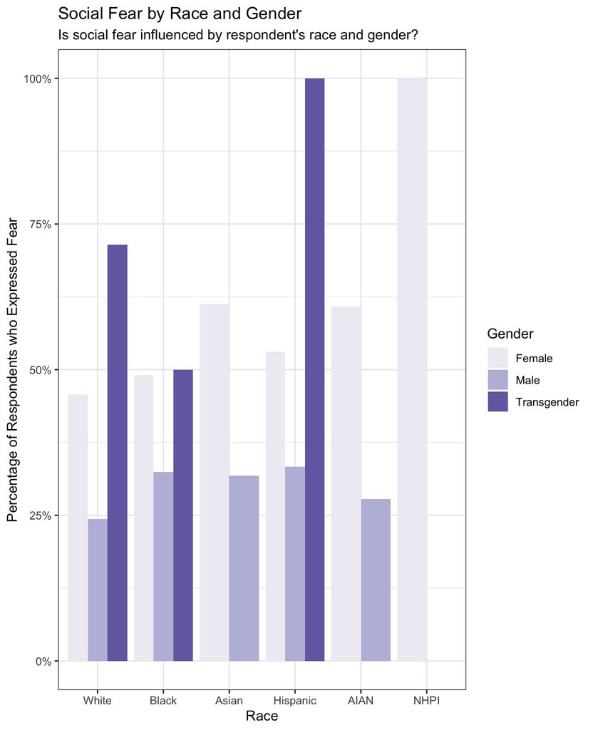

Figure 1: Bar graph showing the percentage of respondants, by race and gender, that responded affirmative to GSS question, Is there any area right around here–that is, within a mile–where you would be afraid to walk alone at night?

```r
gss_subset %>%
  filter(!is.na(racecombo)) %>%
  filter(racecombo != "Other") %>%
  filter(!is.na(sexnow1)) %>%
  filter(sexnow1 != "None of these") %>%
  group_by(racecombo, sexnow1) %>%
  summarize(fear = sum(fear == "yes"),
            n = n(),
            prop = fear/n) %>%
  ggplot(aes(x = racecombo, y = prop)) +
  geom_col(aes(fill = sexnow1), position = "dodge") +
  scale_fill_brewer(palette = "Purples") +
  scale_y_continuous(labels = scales::percent) +
  labs(title = "Social Fear by Race and Gender",
       subtitle = "Is social fear influenced by respondent's race and gender?",
       x = "Race",
       y = "Percentage of Respondents who Expressed Fear") +
  theme_bw() +
  guides(fill = guide_legend(title = "Gender"))
```

Moving on to measures of social embeddedness, we examined fear across degrees of religious participation, degree of happiness and health, residential diversity, and sexual activity. Regarding religious participation, we did not discern any clear pattern. Across all frequencies of religious activity attendance, ranging from “Never” to “Nearly every week”, the percentages of respondents who reported fear at night were all close to 40%, as Figure 2 displays below. The one outlier is attending religious services “about once a month”, which we have no theoretical backings for and is likely attributable to sampling issues.

**View Code**

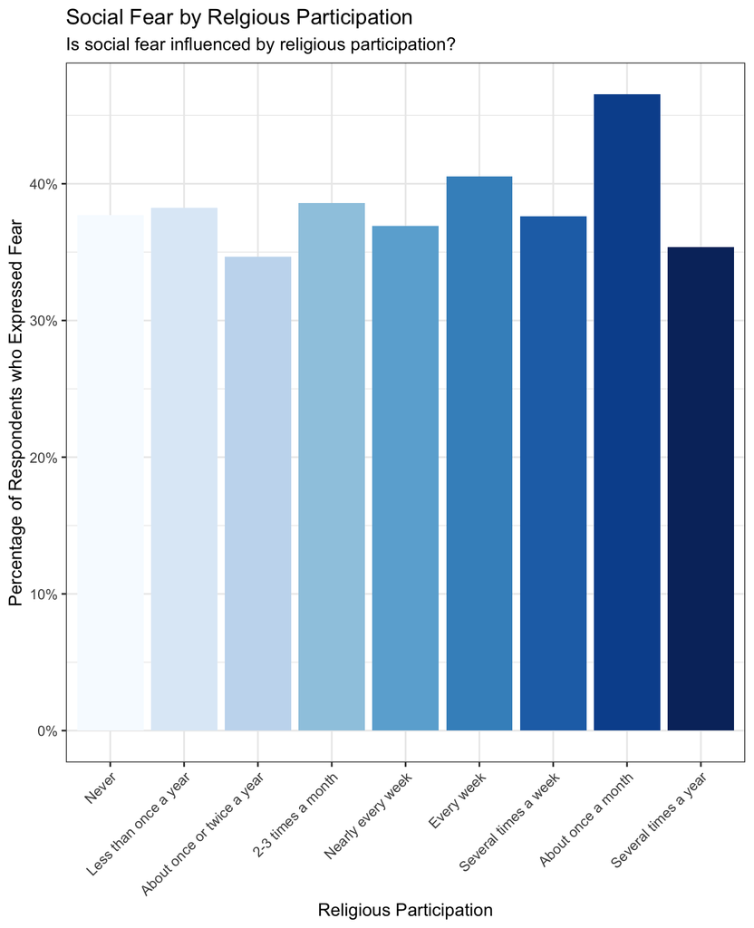

Figure 2: Bar graph showing the percentage of respondants, by degree of participation in religious activities, that responded affirmative to GSS question, Is there any area right around here–that is, within a mile–where you would be afraid to walk alone at night?

```r
gss_subset %>%
  filter(!is.na(attend)) %>%
  group_by(attend) %>%
  summarize(fear = sum(fear == "yes"),
            n = n(),
            prop = fear/n) %>%
  ggplot(aes(x = attend, y = prop, fill = attend)) +
  geom_col() +
  scale_fill_brewer(palette = "Blues") +
  scale_y_continuous(labels = scales::percent) +
  labs(title = "Social Fear by Relgious Participation",
       subtitle = "Is social fear influenced by religious participation?",
       x = "Religious Participation",
       y = "Percentage of Respondents who Expressed Fear") +
  theme_bw() +
  guides(fill = "none") +
  theme(axis.text.x = element_text(angle = 45, vjust = 1, hjust=1))
```

Next, looking at residential composition and race combined displayed in Figure 3, we do notice a pattern where respondents living in residentially more diverse areas were more likely to respond affirmative to the question of social fear. This indicates the sentiment that respondents felt safer and more comfortable living in neighborhoods where other residents share their racial identities, which speaks to the reality of racial residential segregation and its impact on health (Charles 2003; Williams and Collins 2016).

**View Code**

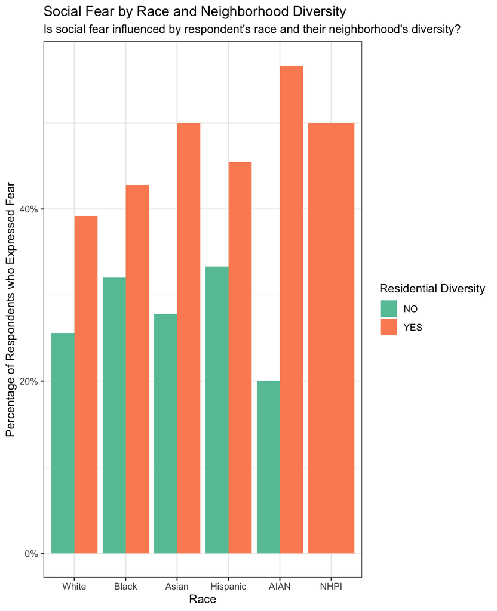

Figure 3: Bar graph showing the percentage of respondants, based on race and neighborhood diversity, that responded affirmative to GSS question, Is there any area right around here–that is, within a mile–where you would be afraid to walk alone at night?

```r
gss_subset %>%
  filter(!is.na(racecombo)) %>%
  filter(racecombo != "Other") %>%
  filter(!is.na(raclive)) %>%
  group_by(racecombo, raclive) %>%
  summarize(fear = sum(fear == "yes"),
            n = n(),
            prop = fear/n) %>%
  ggplot(aes(x = racecombo, y = prop)) +
  geom_col(aes(fill = raclive), position = "dodge") +
  scale_fill_brewer(palette = "Set2") +
  scale_y_continuous(labels = scales::percent) +
  labs(title = "Social Fear by Race and Neighborhood Diversity",
       subtitle = "Is social fear influenced by respondent's race and their neighborhood's diversity?",
       x = "Race",
       y = "Percentage of Respondents who Expressed Fear") +
  theme_bw() +
  guides(fill = guide_legend(title = "Residential Diversity"))
```

What’s more, looking at measures of individual-level characteristics like Happiness and Health, we found that generally as happiness and health increase, social fear decreases. This is shown in Figure 4 and Figure 5. This finding resonates with recent scholarship on the direct relationship between fear of crime and subject well-being that higher levels of happiness and better physical health are associated with lower levels of fear (Krulichová et al. 2018).

**View Code**

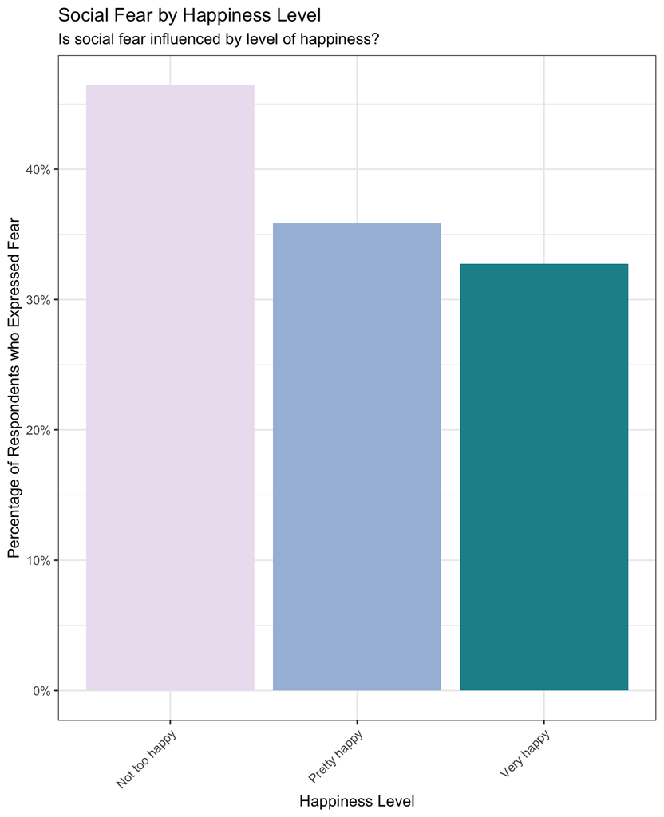

Figure 4: Bar graph showing the percentage of respondants, by happiness levels, that responded affirmative to GSS question, Is there any area right around here–that is, within a mile–where you would be afraid to walk alone at night?

```r
gss_subset %>%
  filter(!is.na(happy)) %>%
  group_by(happy) %>%
  summarize(fear = sum(fear == "yes"),
            n = n(),
            prop = fear/n) %>%
  ggplot(aes(x = happy, y = prop, fill = happy)) +
  geom_col() +
  scale_fill_brewer(palette = "PuBuGn") +
  scale_y_continuous(labels = scales::percent) +
  labs(title = "Social Fear by Happiness Level",
       subtitle = "Is social fear influenced by level of happiness?",
       x = "Happiness Level",
       y = "Percentage of Respondents who Expressed Fear") +
  theme_bw() +
  guides(fill = "none") +
  theme(axis.text.x = element_text(angle = 45, vjust = 1, hjust=1))
```

**View Code**

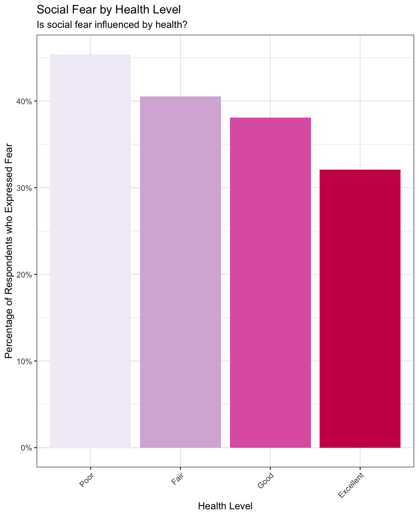

Figure 5: Bar graph showing the percentage of respondants, by health levels, that responded affirmative to GSS question, Is there any area right around here–that is, within a mile–where you would be afraid to walk alone at night?

```r
gss_subset %>%
  filter(!is.na(health)) %>%
  group_by(health) %>%
  summarize(fear = sum(fear == "yes"),
            n = n(),
            prop = fear/n) %>%
  ggplot(aes(x = health, y = prop, fill = health)) +
  geom_col() +
  scale_fill_brewer(palette = "PuRd") +
  scale_y_continuous(labels = scales::percent) +
  labs(title = "Social Fear by Health Level",
       subtitle = "Is social fear influenced by health?",
       x = "Health Level",
       y = "Percentage of Respondents who Expressed Fear") +
  theme_bw() +
  guides(fill = "none") +
  theme(axis.text.x = element_text(angle = 45, vjust = 1, hjust=1))
```

Lastly, we looked at sexual activity as a marker of social fear as represented in Figure 6. Overall, it could be implied that having more sexual partners is positively associated with experiencing fear of walking alone at night, especially for indivuals who reported having had over 20 sexual partners in the last 5 years. A potential explanation is that having more than 20 sexual partners is indicative of a more sexually exploratory and adventurous lifestyle, which brings more exposure to unfamiliar social contacts and environments. We take notice that, interestingly, Females with less than 5 sexual partners in the last 5 years reported lower rates of fear at night compared to Females who reported having 0 sexual partneres. Our interpretation is that those in the “Less than 5 (sexual partners)” group are more likely to have had stable, longer-term sexual relationships, which may have brought a certain sense of security and even cohabiting partners.

**View Code**

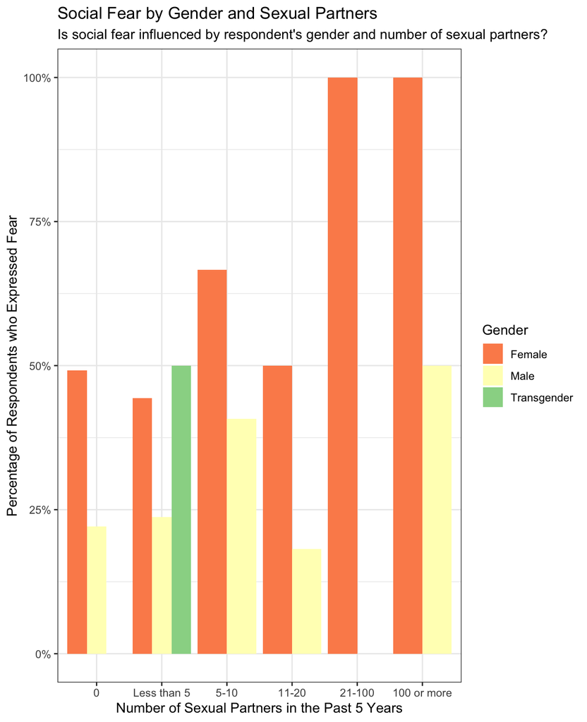

Figure 6: Bar graph showing the percentage of respondants, by gender and number of sexual partners in the past 5 years, that responded affirmative to GSS question, Is there any area right around here–that is, within a mile–where you would be afraid to walk alone at night?

```r
gss_subset %>%
  filter(!is.na(partnrs5)) %>%
  filter(!is.na(sexnow1)) %>%
  filter(sexnow1 != "None of these") %>%
  group_by(partnrs5, sexnow1) %>%
  summarize(fear = sum(fear == "yes"),
            n = n(),
            prop = fear/n) %>%
  ggplot(aes(x = partnrs5, y = prop)) +
  geom_col(aes(fill = sexnow1), position = "dodge") +
  scale_fill_brewer(palette = "Spectral") +
  scale_y_continuous(labels = scales::percent) +
  labs(title = "Social Fear by Gender and Sexual Partners",
       subtitle = "Is social fear influenced by respondent's gender and number of sexual partners?",
       x = "Number of Sexual Partners in the Past 5 Years",
       y = "Percentage of Respondents who Expressed Fear") +
  theme_bw() +
  guides(fill = guide_legend(title = "Gender"))
```

# Discussion

Previous research on fear at night has attended to differences between women and men, and among sexual minority populations [Meyer and Denise (2014); otis2007]. This line of research, however, has not fully examined the intersectional effects of various social dimensions on fear at night, such as race, sexual orientation, gender, and community composition. To be specific, although significant gender differences have been documented (Cops and Pleysier 2011; Elizabeth Anne Stanko 1990), wherein women are more likely than men to report fear, research has failed to consider the complex ways in which other social dimensions such as race may intersect with regard to such fear.

Our assessment of fear relies on a single measure—fear of walking alone at night—that does not explicitly ask respondents about what, in particular, they fear. Potential objects or events in question would be robbery, sexual assault, verbal harassment, or sexual orientation- or religion-based hate crimes. And with common sense, we know that people embodying different identities and self-presentations will be vulnerable to different forms of street crimes. Further research should explore the particular nature of this fear, and whether it is based on crime victimization experience or verbal harassment.

The R tools we learned from the class “EDLD 651: Intro to R” have been extremely helpful in cleaning and visualizing the data.

## References

Bennett, Richard R, and Jeanne M Flavin. 1994. “Determinants of Fear of Crime: The Effect of Cultural Setting.” *Justice Quarterly* 11 (3): 357–81.

Bonilla-Silva, Eduardo. 2022. *Racism Without Racists: Colorblind Racism and the Persistence of Racial Inequality in America*. 6th ed. Rowman & Littlefield Publishing Group.

Charles, Camille Zubrinsky. 2003. “The Dynamics of Racial Residential Segregation.” *Annual Review of Sociology* 29 (1): 167–207.

Cops, Diederik, and Stefaan Pleysier. 2011. “‘Doing Gender’in Fear of Crime: The Impact of Gender Identity on Reported Levels of Fear of Crime in Adolescents and Young Adults.” *The British Journal of Criminology* 51 (1): 58–74.

Dowling, Julie A. 2014. *Mexican Americans and the Question of Race*. University of Texas Press. https://doi.org/10.7560/754010.

Dwyer-Lindgren, Laura, Johan P Mackenbach, Frank J van Lenthe, and Ali H Mokdad. 2017. “Self-Reported General Health, Physical Distress, Mental Distress, and Activity Limitation by US County, 1995-2012.” *Population Health Metrics* 15: 1–12.

Golash-Boza, Tanya Maria. 2015. *Deported: Immigrant Policing, Disposable Labor, and Global Capitalism*. Latina/o Sociology Series. New York University Press.

Hale, Chris. 1996. “Fear of Crime: A Review of the Literature.” *International Review of Victimology* 4 (2): 79–150.

Haney-López, Ian. 2006. *White by Law: The Legal Construction of Race*. Rev. and updated, 10th anniversary ed. Critical America. New York University Press.

Hough, Mike, Patricia Mayhew, et al. 1983. *The British Crime Survey: First Report*. Vol. 76. HM Stationery Office Ixindon.

Kawachi, Ichiro. 1999. “Social Capital and Community Effects on Population and Individual Health.” *Annals of the New York Academy of Sciences* 896 (1): 120–30.

Kline, Nolan. 2019. *Pathogenic Policing: Immigration Enforcement and Health in the US South*. Medical Anthropology: Health, Inequality, and Social Justice. Rutgers University Press.

Krieger, Nancy. 2001. “Theories for Social Epidemiology in the 21st Century: An Ecosocial Perspective.” *International Journal of Epidemiology* 30 (4): 668–77.

Krulichová, Eva et al. 2018. “Life Satisfaction and Happiness: Discussing the Impact of Fear of Crime and Victimization.” *Acta Universitatis Carolinae Philosophica Et Historica* 24 (2): 23–37.

Lacayo, Celia Olivia. 2017. “Perpetual Inferiority: Whites’ Racial Ideology Toward Latinos.” *Sociology of Race and Ethnicity* 3 (4): 566–79. https://doi.org/10.1177/2332649217698165.

LaGrange, Randy L, and Kenneth F Ferraro. 1989. “Assessing Age and Gender Differences in Perceived Risk and Fear of Crime.” *Criminology* 27 (4): 697–720.

Madriz, Esther. 2023. *Nothing Bad Happens to Good Girls: Fear of Crime in Women’s Lives*. Univ of California Press.

Massey, Douglas S. 2020. “Still the Linchpin: Segregation and Stratification in the USA.” *Race and Social Problems* 12 (1): 1–12. https://doi.org/10.1007/s12552-019-09280-1.

McCall, Leslie. 2005. “The Complexity of Intersectionality.” *Signs: Journal of Women in Culture and Society* 30 (3): 1771–1800.

Meyer, Doug, and Eric Joy Denise. 2014. “Sexual Orientation and Fear at Night: Gender Differences Among Sexual Minorities and Heterosexuals.” *Journal of Homosexuality* 61 (4): 453–70.

Mora, Cristina G. 2014. *Making Hispanics: How Activists, Bureaucrats, and Media Constructed a New American*. University of Chicago Press. https://doi.org/10.7208/chicago/9780226033976.001.0001.

Moran, Leslie J, Beverley Skeggs, Paul Tyrer, and Karen Corteen. 2003. “The Formation of Fear in Gay Space: The ‘Straights’ Story.” *Capital & Class* 27 (2): 173–98.

O’Brien, Eileen. 2008. *The Racial Middle: Latinos and Asian Americans Living Beyond the Racial Divide*. New York University Press.

Omi, Michael, and Howard Winant. 2015. *Racial Formation in the United States*. Third edition. Routledge/Taylor & Francis Group.

Otis, Melanie D. 2007. “Perceptions of Victimization Risk and Fear of Crime Among Lesbians and Gay Men.” *Journal of Interpersonal Violence* 22 (2): 198–217.

Rodriguez, Clara E. 2000. *Changing Race: Latinos, the Census, and the History of Ethnicity in the United States*. Critical America. New York University Press.

Rountree, Pamela Wilcox, and Kenneth C Land. 1996. “Perceived Risk Versus Fear of Crime: Empirical Evidence of Conceptually Distinct Reactions in Survey Data.” *Social Forces* 74 (4): 1353–76.

Schilt, Kristen, and Laurel Westbrook. 2009. “Doing Gender, Doing Heteronormativity: ‘Gender Normals,’ Transgender People, and the Social Maintenance of Heterosexuality.” *Gender & Society* 23 (4): 440–64.

Schnitzer, Susanne, Mark A Bellis, Zara Anderson, Karen Hughes, Amador Calafat, Montse Juan, and Anna Kokkevi. 2010. “Nightlife Violence: A Gender-Specific View on Risk Factors for Violence in Nightlife Settings: A Cross-Sectional Study in Nine European Countries.” *Journal of Interpersonal Violence* 25 (6): 1094–1112.

Snedker, Karen A. 2006. “Altruistic and Vicarious Fear of Crime: Fear for Others and Gendered Social Roles.” In *Sociological Forum*, 21:163–95. Springer.

Stanko, Elizabeth A. 1993. “The Case of Fearful Women: Gender, Personal Safety and Fear of Crime.” *Women & Criminal Justice* 4 (1): 117–35.

Stanko, Elizabeth Anne. 1990. “Everyday Violence: How Women and Men Experience Sexual and Physical Danger.” *(No Title)*.

Warr, Mark. 1990. “Dangerous Situations: Social Context and Fear of Victimization.” *Social Forces* 68 (3): 891–907.

Williams, David R, and Chiquita Collins. 2016. “Racial Residential Segregation: A Fundamental Cause of Racial Disparities in Health.” *Public Health Reports*.